# How to choose Beer with MDS

Timur Sharifullin

2023-03-15

```r
# choose the variables
pivo = pivo[,c(2,4,5,6,9,10,11)]

# aggregated ratings
pivo_summary <- pivo %>%
  group_by(beer_name, brewery_name) %>%
  dplyr::summarize(across(c(review_overall, review_aroma, review_appearance, review_palate, review_taste), median,
                          .names = "{col}"))

# filtering by one brewing company
pivo_dark = pivo_summary %>% filter(brewery_name == "Dark Horse Brewing Company") %>% as.data.frame()

rownames(pivo_dark) = pivo_dark$beer_name
pivo_dark = select(pivo_dark,-brewery_name,-beer_name)
head(pivo_dark)
```

```
##                                 review_overall review_aroma review_appearance
## AK 47 Chocolate Hazelnut Porter           3.50          3.5              3.50
## Aigre (Sour) Plead The 5th                4.00          4.0              3.25
## Beer With Grain                           3.00          3.0              4.00
## Belgian IPA                               4.00          4.0              4.25
## Blueberry Honey Biscuit Monkey            3.75          4.0              3.50
## Caramel Apple Aley                        4.00          4.0              4.00
##                                 review_palate review_taste
## AK 47 Chocolate Hazelnut Porter          3.25         3.50
## Aigre (Sour) Plead The 5th               4.00         4.00
## Beer With Grain                          3.00         3.00
## Belgian IPA                              4.00         4.00
## Blueberry Honey Biscuit Monkey           3.75         3.75
## Caramel Apple Aley                       4.00         3.50
```

I used Beer Reviews for this project, however, it has too many observations(1.5 million), so firstly I aggregated the median review rating for every beer and then I cut the dataset to analyze only “Dark Horse Brewing Company” products

```r
matrixxx = dist(pivo_dark)
```

```r
ratio = mds(matrixxx, type = "ratio")
ratio
```

```
##
## Call:
## mds(delta = matrixxx, type = "ratio")
##
## Model: Symmetric SMACOF
## Number of objects: 72
## Stress-1 value: 0.09
## Number of iterations: 29
```

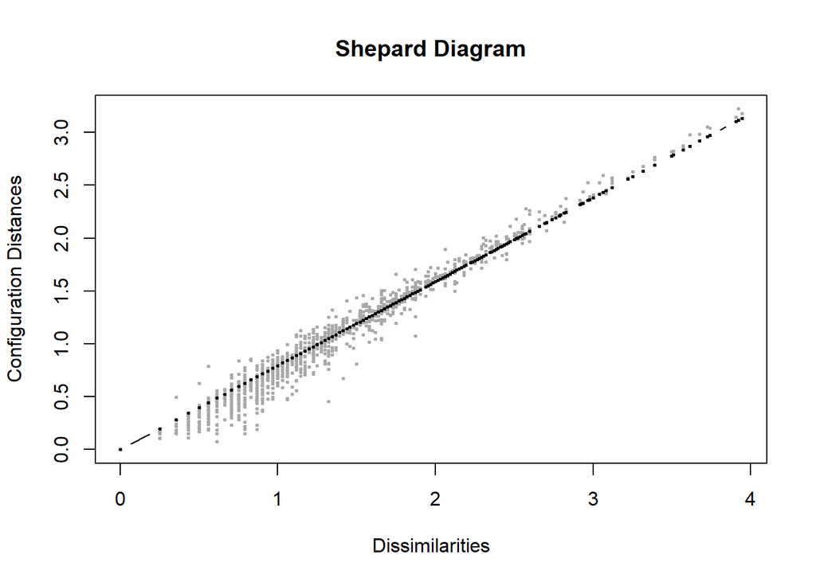

```r
plot(ratio, plot.type = "Shepard")
```

```r
interval = mds(matrixxx, type = "interval")
interval
```

```
##
## Call:
## mds(delta = matrixxx, type = "interval")
##
## Model: Symmetric SMACOF
## Number of objects: 72
## Stress-1 value: 0.08
## Number of iterations: 27
```

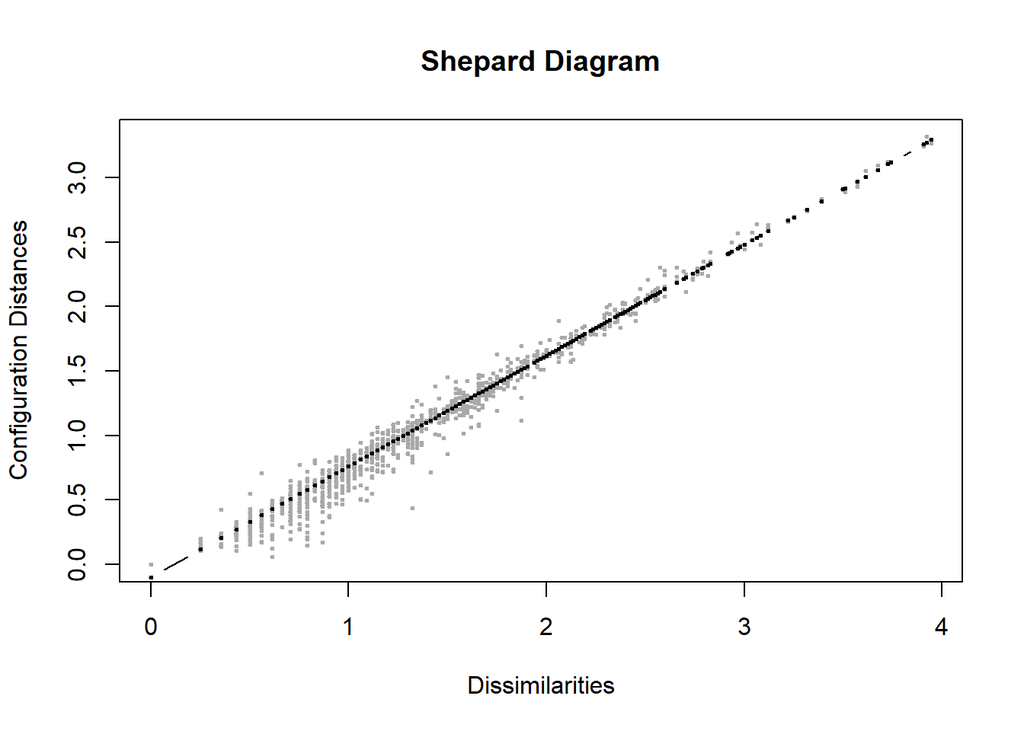

```r
plot(interval, plot.type = "Shepard")
```

```r
ordinal = mds(matrixxx, type = "ordinal")
ordinal
```

```
##
## Call:
## mds(delta = matrixxx, type = "ordinal")
##
## Model: Symmetric SMACOF
## Number of objects: 72
## Stress-1 value: 0.056
## Number of iterations: 26
```

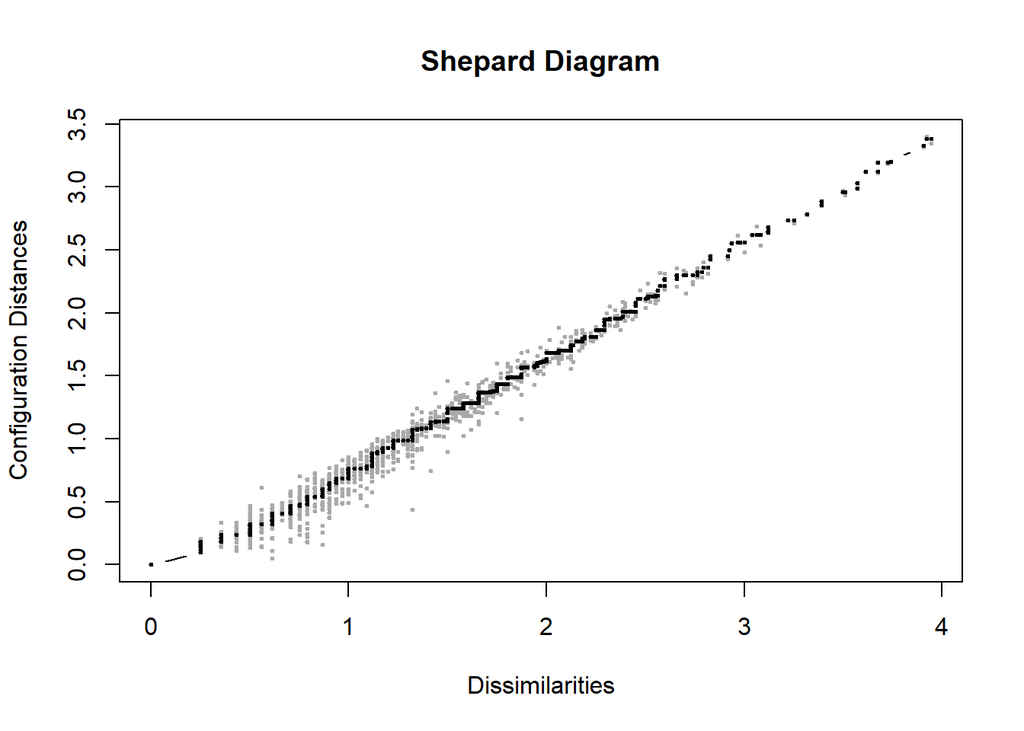

```r
plot(ordinal, plot.type = "Shepard")
```

```r
mspline = mds(matrixxx, type = "mspline")
mspline
```

```
##
## Call:
## mds(delta = matrixxx, type = "mspline")
##
## Model: Symmetric SMACOF
## Number of objects: 72
## Stress-1 value: 0.074
## Number of iterations: 25
```

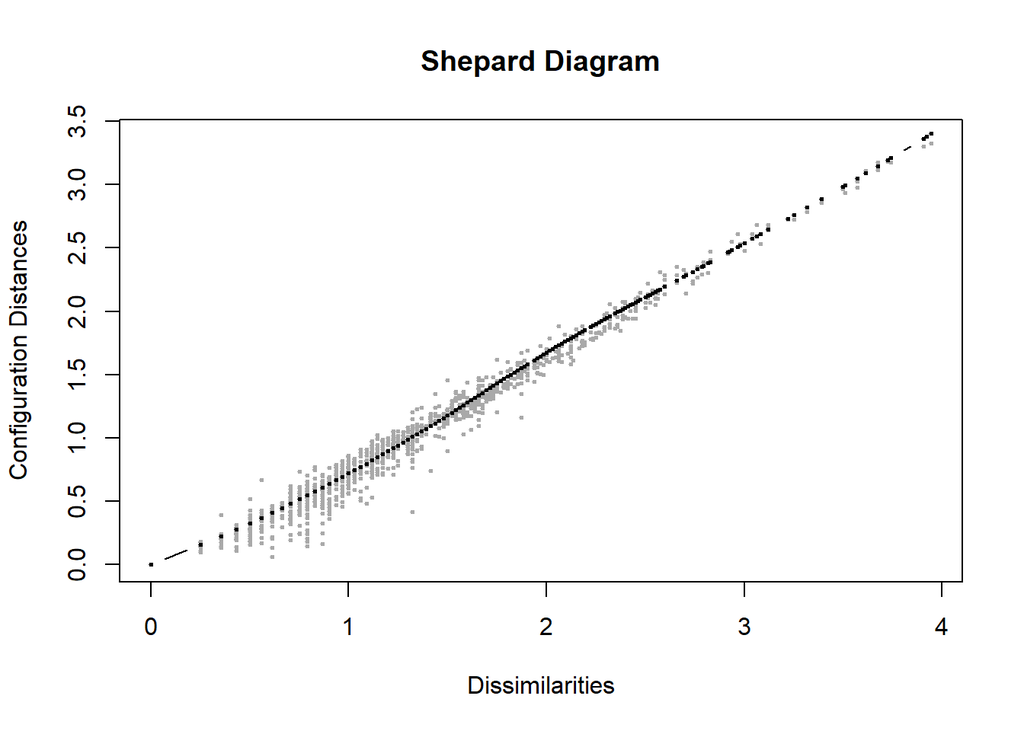

```r
plot(mspline, plot.type = "Shepard")
```

It seems that ordinal type of MDS has the best fit, both by shepard diagram and Stress-1 value (good fit)

```r
head(as.data.frame(sort(ordinal$spp,decreasing=T)),20)
```

```
##                                               sort(ordinal$spp, decreasing = T)
## Dark Horse Eaton County Special Reserve                                5.938035
## Caramel Apple Aley                                                     5.510272
## SO IN Oats                                                             5.510272
## Dark Horse Rod                                                         4.905458
## Plead The Option                                                       4.657941
## Aigre (Sour) Plead The 5th                                             4.212779
## Dark Horse Judson's Juice Pale Ale                                     3.561317
## Raspberry Icee Black                                                   3.455048
## Frog Island Spruce Ale (brewed By Dark Horse)                          3.151452
## Raspberry Black Ice                                                    2.869006
## Hunt Club House Ale                                                    2.638323
## King Of The Forest                                                     2.390046
## Dark Horse Bitter Berry                                                2.350819
## Beer With Grain                                                        2.293220
## Dark Horse 3 Guys Running                                              2.001011
## Belgian IPA                                                            1.879186
## Dark Horse Whiskey Richard Lambeak                                     1.841433
## WGRD                                                                   1.813053
## Dark Horse Lambdick Framboozin                                         1.805369
## Dark Horse Say Zon                                                     1.664025
```

As for stress per point there is no visible outliers.

```r
jackmds(ordinal)
```

```
##
## Call: jackmds.smacofB(object = ordinal)
##
## SMACOF Jackknife
## Number of objects: 72
## Value loss function: 0.573
## Number of iterations: 7
##
## Stability measure: 0.9998
## Cross validity: 1
## Dispersion: 2e-04
```

Jackknife strategy for MDS for examination of the stability of a solution shows perfect results - Stability measure is almost 1, Cross validity = 1. So, the model is stable and valid

```r
bootsi_i_pivo = bootmds(ordinal, as.data.frame(t(pivo_dark)), method.dat = "euclidean", nrep = 300)
bootsi_i_pivo
```

```
##
## Call: bootmds.smacofB(object = ordinal, data = as.data.frame(t(pivo_dark)),
##     method.dat = "euclidean", nrep = 300)
##
## SMACOF Bootstrap:
## Number of objects: 72
## Number of replications: 300
##
## Mean bootstrap stress:  0.0377
## Stress percentile CI:
##   2.5%  97.5%
## 0.0000 0.0661
##
## Stability coefficient: 0.9158
```

Finally, the stability coefficient of 0.9158 suggests that the MDS solution is quite stable, as it indicates that approximately 91% of the variability in the original solution is preserved in the bootstrap replicates.

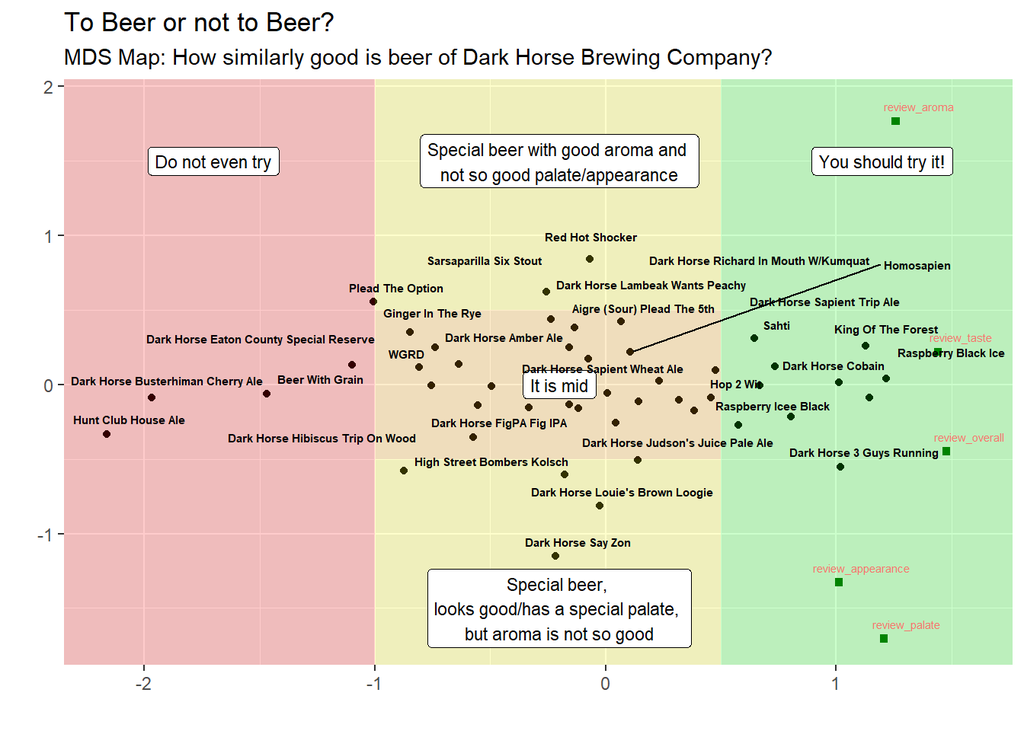

```r
plot_data = as.data.frame(ordinal$conf)
bi_points = biplotmds(ordinal,extvar=pivo_dark)$coefficients %>% t() %>% as.data.frame()

ggplot() +
  geom_point(data= plot_data, aes(x = D1, y = D2)) +
  geom_point(data = bi_points, aes(x = D1, y = D2), color = "darkgreen", shape = "square") +

  geom_rect(aes(xmin = -Inf, xmax = -1, ymin = -Inf, ymax = Inf),
            fill = "red", alpha = 0.2) +
  geom_label(aes(x=-1.7, y=1.5, label="Do not even try"),size=3) +

  geom_rect(aes(xmin = -1, xmax = 0.5, ymin = -Inf, ymax = -0.5),
            fill = "yellow", alpha = 0.2) +
  geom_label(aes(x=-0.2, y=-1.5, label="Special beer,
looks good/has a special palate,
but aroma is not so good"),size=3) +

  geom_rect(aes(xmin = -1, xmax = 0.5, ymin = 0.5, ymax = Inf),
            fill = "yellow", alpha = 0.2) +
  geom_label(aes(x=-0.2, y=1.5, label="Special beer with good aroma and
not so good palate/appearance"),size=3) +

  geom_rect(aes(xmin = -1, xmax = 0.5, ymin = -0.5, ymax = 0.5),
            fill = "orange", alpha = 0.2) +
  geom_label(aes(x=-0.2, y=0, label="It is mid"),size=3) +

  geom_rect(aes(xmin = 0.5, xmax = Inf, ymin = -Inf, ymax = Inf),
            fill = "green", alpha = 0.2) +
  geom_label(aes(x=1.2, y=1.5, label="You should try it!"),size=3) +

  geom_text_repel(data = plot_data, aes(x = D1, y = D2, label = row.names(plot_data)),
                size = 2, fontface = 'bold', min.segment.length = 8,
                nudge_x = 0.1, nudge_y = 0.1, direction = "both") +

  geom_text_repel(data = bi_points, aes(x = D1, y = D2, label = row.names(bi_points), color = "green"),
                size = 2, min.segment.length = 8,
                nudge_x = 0.1, nudge_y = 0.1, direction = "both") +

  labs(x ="", y = "", title = "To Beer or not to Beer?",
       subtitle = "MDS Map: How similarly good is beer of Dark Horse Brewing Company?") +

  theme(legend.position = "none")
```

5.Despite the fact, that it is not really appropriate to interpret the dimensions of the MDS, it seems that all of the beer qualities “vectors” are directed to the right, so we really can say, that the better the beer the more right on the plot it is. Green and red regions are more similar in terms of y-axis than mid (yellow and orange) sectors. So, if the beer is bad - it is just bad (the same with good), but if the beer is not so good and not so bad - maybe it is not mid, but just special.